# Brain stroke

# Goal of collecting this Dataset

Our goal of collecting a dataset about brain stroke is to gather relevant and accurate information about this medical condition by gathering information about the patients health history,age and gender.This data will help enhancing patient care so that researchers and healthcare professionals can gain knowledge of the risk factors ,causes, age rating of patients and symptoms associated with brain stroke.

# Classification goal:

We want to classify the patients to be able to accurately predict whether a patient will have a stroke or not based on age, medical history and gender. Using this classification we can help in early identification and prevention of strokes ,this would help us for a better patient care.

# Clustering goal:

The goal of clustering is to identify patterns or groupings within the data that can help in better understanding the risk factors of brain stroke. It can help to categorize similar cases or patients, which might be useful for research, diagnosis and treatment planning.

The Problem statement: To use data mining techniques to help researchers for early detection, risk assessment, and improved understanding of brain strokes, explore the given dataset on brain stroke and develop a predictive model that can identify the key risk factors associated with stroke. Specifically, the project aims to:

1. Perform exploratory data analysis to gain insights into the distribution and characteristics of the variables in the dataset.
2. Identify the most significant variables and their relationships with stroke occurrence using statistical analysis and data visualization techniques.
3. Preprocess the dataset by handling missing values, outliers, and categorical variables, ensuring data quality and consistency.
4. Select appropriate data mining techniques, such as classification algorithms, to build a predictive model for stroke risk assessment.

# The source

The dataset was sourced from kaggle website The link: [here](https://www.kaggle.com/datasets/jillanisofttech/brain-stroke-dataset).

# General information

1. gender: “Male”, “Female”
2. age: age of the patient
3. hypertension: 0 if the patient doesn’t have hypertension, 1 if the patient has hypertension
4. heart disease: 0 if the patient doesn’t have any heart diseases, 1 if the patient has a heart disease
5. Ever-married: “No” or “Yes”
6. work type: “children”, “Govt_job”, “Never worked”, “Private” or “Self-employed”
7. Residence type: “Rural” or “Urban”
8. avg glucose level: average glucose level in blood
9. BMI: body mass index
10. smoking_status: “formerly smoked”, “never smoked”, “smokes” or “Unknown”
11. stroke: 1 if the patient had a stroke or 0 if not

    | attribute name | data type | description | possible values |
    | --- | --- | --- | --- |
    | gender | string | Gender of the patient (e.g., Male, Female). | Male, Female |
    | Age | decimal | Patient’s age in years at the time of assessment | 0.08 to 82 |
    | h yp ertension | integer | if the patient has h ypertension | 0 or 1 |
    | heart disease | integer | if the patient has heart disease | 0 or 1 |
    | Residence type | string | the residence type of the patient | “Rural” or “Urban” |
    | E ve r-married | string | if the patient has ever married or not | “No” or “Yes” |
    | work type | string | the work type of the patient | “children”, “Govt_job”, “Never worked”, “Private” or ” S e l f-employed” |
    | avg glucose level | decimal | average glucose level in blood | 55.1 - 272 |
    | BMI | decimal | Body Mass Index (BMI) of the patient. | 14 - 48.9 |
    | smoking status | string | the smoking status of the patient | “formerly smoked”, “never smoked”, “smokes” or “Unknown” |
    | stroke | integer | if the patient had a stroke or not | 0 or 1 |

# Summarization

**Load dataset**

```r
library(readr)
brain_stroke <- read_csv("brain_stroke.csv")
View(brain_stroke)
```

**Load necessary libraries**

```r
library(dplyr)
library(ggplot2)
library(outliers)
```

**Number of rows**

```r
nrow(brain_stroke)
```

```
[1] 4981
```

**Number of columns**

```r
 ncol(brain_stroke)
```

```
[1] 11
```

**Sample of raw dataset**

```r
head(brain_stroke,n=10)
```

| gender | age | hypertension | heart_disease | ever_married | work_type | Residence_type | avg_glucose_level | bmi | smoking_status | stroke |
| --- | --- | --- | --- | --- | --- | --- | --- | --- | --- | --- |
| Male | 67 | 0 | 1 | Yes | Private | Urban | 228.69 | 36.6 | formerly smoked | 1 |
| Male | 80 | 0 | 1 | Yes | Private | Rural | 105.92 | 32.5 | never smoked | 1 |
| Female | 49 | 0 | 0 | Yes | Private | Urban | 171.23 | 34.4 | smokes | 1 |
| Female | 79 | 1 | 0 | Yes | Self-employed | Rural | 174.12 | 24.0 | never smoked | 1 |
| Male | 81 | 0 | 0 | Yes | Private | Urban | 186.21 | 29.0 | formerly smoked | 1 |
| Male | 74 | 1 | 1 | Yes | Private | Rural | 70.09 | 27.4 | never smoked | 1 |
| Female | 69 | 0 | 0 | No | Private | Urban | 94.39 | 22.8 | never smoked | 1 |
| Female | 78 | 0 | 0 | Yes | Private | Urban | 58.57 | 24.2 | Unknown | 1 |
| Female | 81 | 1 | 0 | Yes | Private | Rural | 80.43 | 29.7 | never smoked | 1 |
| Female | 61 | 0 | 1 | Yes | Govt_job | Rural | 120.46 | 36.8 | smokes | 1 |

```r
NA
```

**Missing values**

```r
is.na(brain_stroke)
sum(is.na(brain_stroke))
```

**Statistical summaries**

```r
summary(brain_stroke$age)
```

The age ranges from a minimum of 0.08 to a maximum of 82.00, with most values concentrated between the first quartile (25.00) and the third quartile (61.00) and The median age is 45.00, and the mean age is approximately 43.42 , it is relatively wide age range with a skewed distribution towards older ages

```r
summary(brain_stroke$avg_glucose_level)
```

The average glucose levels shows that they range from a minimum of 55.12 to a maximum of 271.74, with a median value of 91.85 and a mean of 105.94, Most values are concentrated between the first quartile (77.23) and the third quartile (113.86), This suggests some variability in glucose levels, with a slightly right-skewed distribution.

```r
summary(brain_stroke$bmi)
```

the BMI data has a minimum value of 14.0 and a maximum of 48.9, with the median BMI being 28.1 and the mean approximately 28.5, The majority of values fall between the first quartile (23.7) and the third quartile (32.6), This indicates a range of BMI values with a distribution that appears to be somewhat right-skewed.

```r
var(brain_stroke$age)
```

The variance of age in your dataset is 513.6005, This measures the spread or variability in age values, A higher variance suggests a wider dispersion of ages in the dataset, indicating greater variability.

```r
var(brain_stroke$avg_glucose_level)
```

The variance of average glucose levels is 2031.789, This high variance suggests a considerable amount of variation in glucose levels among the individuals in the dataset.

```r
var(brain_stroke$bmi)
```

The variance of BMI is 46.1104,it indicates a moderate amount of variability in BMI values within the dataset.

## **Boxplots**

**boxplot of age**

boxplot to visualize the distribution of ages in our dataset, it includes the median, quartiles, and potential outliers of the age variable.

```r
 boxplot.stats(brain_stroke$age)$out
 boxplot(brain_stroke$age)
```

**boxplot of avg_glucose_level**

boxplot to visualize the distribution of avg_glucose_level in our dataset, it includes the median, quartiles, and potential outliers of the avg_glucose_level variable.

```r
boxplot.stats(brain_stroke$avg_glucose_level)$out
boxplot(brain_stroke$avg_glucose_level)
```

**boxplot of bmi**

a boxplot to visualize the distribution of bmi in our dataset, it includes the median, quartiles, and potential outliers of the bmi variable.

```r
boxplot.stats(brain_stroke$bmi)$out
boxplot(brain_stroke$bmi)
```

## **histogram**

**Shows Distribution of ages**

```r
hist(brain_stroke$age, col = "purple", main = "Age Distribution", xlab
= "Age")
```

We notice from this histogram that the majority of people in this dataset are between the ages of 40 to 60

## **Scatter plot**

**Shows the relationship between two attributes: “average glucose level” (on the x-axis) and “BMI” (Body Mass Index, on the y-axis)**

```r
ggplot(brain_stroke, aes(x = avg_glucose_level, y = bmi)) +
geom_point() + labs(title = "Scatter Plot: BMI & average glucose level")

cor(brain_stroke$avg_glucose_level, brain_stroke$bmi)
```

[1] 0.1863482 Based on the scatter plot and the correlation number We noticed that the correlation between the two attributes is very weak because the correlation is between 0 and 0.199.

## Pie charts

**Shows Distribution of Residence Types**

```r
tab <- table(brain_stroke$Residence_type)

percentages <- prop.table(tab) * 100

txt <- paste0(names(tab), '\n', round(percentages, 3), '%')

pie(tab, labels = txt)
```

We notice from this pie chart that the majority of people in this dataset live in urban residence

## **Bar Plots**

### 1 - Shows the disturbution of work type

```r
library(ggplot2)

# Assuming you have a data frame named 'brain_stroke'

# Define a custom color palette
my_colors <- c("pink", "lightblue", "lightgreen", "purple")  # You can add more colors as needed

ggplot(brain_stroke, aes(x = work_type, fill = work_type)) +
  geom_bar(color = "black", fill = my_colors) +
  labs(title = "Bar Plot: Distribution of Work Type")
```

We notice from this bar plot that the majority of people in this dataset work for a private organization.

After encoding, ‘Children’ will be number 1, ‘Govt_job’ will be number 2, ‘Private’ will be number 3, and ‘Self-employed’ is number 4.

### 2 - The resulting plot visually shows the distribution of heart disease cases and their association with brain stroke.

```r
library(ggplot2)
library(dplyr)

percentages <- brain_stroke %>%
  group_by(heart_disease, stroke) %>%
  summarize(count = n(), .groups = "drop") %>%
  mutate(percentage = (count / sum(count)) * 100)

ggplot(brain_stroke, aes(x = factor(heart_disease), fill = stroke)) +
  geom_bar() +
  geom_text(data = percentages, aes(label = paste0(round(percentage, 1), "%"), y = count),
            position = position_stack(vjust = 0.5)) +
  labs(x = "Heart Disease", y = "Count", fill = "Stroke") +
  scale_x_discrete(labels = c("No Heart Disease", "Heart Disease")) +
  ggtitle("Barplot of Heart Disease and Stroke") +
  theme_minimal()
```

### 3 - The resulting plot visually shows the distribution of hypertension cases and their association with brain stroke.

```r
percentages <- brain_stroke %>%
  group_by(hypertension, stroke) %>%
  summarize(count = n()) %>%
  mutate(percentage = (count / sum(count)) * 100)

ggplot(brain_stroke, aes(x = factor(hypertension), fill = stroke)) +
  geom_bar() +
  geom_text(data = percentages, aes(label = paste0(round(percentage, 1), "%"), y = count),
            position = position_stack(vjust = 0.5)) +
  labs(x = "Hypertension", y = "Count", fill = "Stroke") +
  ggtitle("Barplot of Hypertension and Stroke") +
  scale_x_discrete(labels = c("No Hypertension", "Hypertension")) +  # Custom labels
  theme_minimal()
```

The perecentage at the top of the column shows the percentage of having a brain stroke ,We notice from this bar plot that people with hypertension have a higher risk of experiencing a brain stroke.

### 4 - bar blot that shows the distrbutaion of smoking status.

```r
library(ggplot2)

ggplot(brain_stroke) +
  geom_bar(aes(x = smoking_status, fill = smoking_status)) +
  labs(
    title = " Distrbutaion of smoking status",
    x = "Smoking Status",
    y = "Count",
    fill = "Smoking Status"
  ) +
  scale_fill_manual(values = c("formerly smoked" = "lightblue", "never smoked" = "lightgreen", "smokes" = "pink", "Unknown" = "gray")) +
  theme_minimal()
```

We notice from this code that the majority of people in this dataset have never Smoked.

```r
library(ggplot2)

ggplot(brain_stroke) +
  geom_bar(mapping = aes(x = smoking_status, fill = factor(stroke)), position = "dodge") +
  labs(
    title = "Association Between Stroke and Smoking Status",
    x = "Smoking Status",
    y = "Count",
    fill = "Stroke"
  ) +
  scale_fill_manual(values = c("0" = "blue", "1" = "red")) +
  theme_minimal()
```

We notice from this bar plot that people who formerly smoked and smokes have a higher risk of experiencing a brain stroke, we notice that by comparing between the length of the blue columns which represnt each smoking staus not having a stroke posability against the length of the red column wich represent having stroke*

### 5- Class plot that shows if the dataset is balanced or imbalanced

```r
library(ggplot2)

ggplot(brain_stroke, aes(x = factor(stroke), fill = factor(stroke))) +
  geom_bar() +
  labs(
    title = "Class Distribution of Stroke",
    x = "Stroke",
    y = "Count"
  ) +
  theme_minimal() +
  scale_fill_manual(values = c("0" = "red", "1" = "blue"))
```

This plot shows that our dataset is imbalanced, The “0” column (no stroke) is significantly higher than the “1” column (stroke), it indicates an imbalance in the dataset with respect to the stroke class.

# Pre-Processing

## Outliers

```r
library(outliers)

Outavg_glucose_level = outlier(brain_stroke$avg_glucose_level, logical =TRUE)
sum(Outavg_glucose_level)
Find_outlier = which(Outavg_glucose_level ==TRUE, arr.ind = TRUE)
Outavg_glucose_level
Find_outlier

Outbmi = outlier(brain_stroke$bmi, logical =TRUE)
sum(Outbmi)
Find_outlier = which(Outbmi ==TRUE, arr.ind = TRUE)
Outbmi
Find_outlier

Outage = outlier(brain_stroke$age, logical =TRUE)
sum(Outage)
Find_outlier = which(Outage ==TRUE, arr.ind = TRUE)
Outage
Find_outlier
```

## Normalization

```r
normalize <- function(x) {return ((x - min(x)) / (max(x) - min(x)))}
dataWithoutNormalization <- brain_stroke
brain_stroke$bmi<-normalize(dataWithoutNormalization$bmi)
brain_stroke$age<-normalize(dataWithoutNormalization$age)
brain_stroke$avg_glucose_level<-normalize(dataWithoutNormalization$age)
print(brain_stroke)
```

## Discretization

```r
#we do not need feature discretization because the data is already well-preprocessed.
```

## Feature selection

### correlation

```r
library(outliers)

Outavg_glucose_level = outlier(brain_stroke$avg_glucose_level, logical =TRUE)
sum(Outavg_glucose_level)
```

[output not shown]

```r
Find_outlier = which(Outavg_glucose_level ==TRUE, arr.ind = TRUE)
Outavg_glucose_level
```

```
   [1] FALSE FALSE FALSE FALSE FALSE FALSE FALSE FALSE FALSE FALSE FALSE FALSE FALSE FALSE FALSE FALSE
  [17] FALSE FALSE FALSE FALSE FALSE FALSE FALSE FALSE FALSE FALSE FALSE FALSE FALSE FALSE FALSE FALSE
  [33] FALSE FALSE FALSE FALSE FALSE FALSE FALSE FALSE FALSE FALSE FALSE FALSE FALSE FALSE FALSE FALSE
  [49] FALSE FALSE FALSE FALSE FALSE FALSE FALSE FALSE FALSE FALSE FALSE FALSE FALSE FALSE FALSE FALSE
  [65] FALSE FALSE FALSE FALSE FALSE FALSE FALSE FALSE FALSE FALSE FALSE FALSE FALSE FALSE FALSE FALSE
  [81] FALSE FALSE FALSE FALSE FALSE FALSE FALSE FALSE FALSE FALSE FALSE FALSE FALSE FALSE FALSE FALSE
  [97] FALSE FALSE FALSE FALSE FALSE FALSE FALSE FALSE FALSE FALSE FALSE FALSE FALSE FALSE FALSE FALSE
 [113] FALSE FALSE FALSE FALSE FALSE FALSE FALSE FALSE FALSE FALSE FALSE FALSE FALSE FALSE FALSE FALSE
 [129] FALSE FALSE FALSE FALSE FALSE FALSE FALSE FALSE FALSE FALSE FALSE FALSE FALSE FALSE FALSE FALSE
 [145] FALSE FALSE FALSE FALSE FALSE FALSE FALSE FALSE FALSE FALSE FALSE FALSE FALSE  TRUE FALSE FALSE
 [161] FALSE FALSE FALSE FALSE FALSE FALSE FALSE FALSE FALSE FALSE FALSE FALSE FALSE FALSE FALSE FALSE
 [177] FALSE FALSE FALSE FALSE FALSE FALSE FALSE FALSE FALSE FALSE FALSE FALSE FALSE FALSE FALSE FALSE
 [193] FALSE FALSE FALSE FALSE FALSE FALSE FALSE FALSE FALSE FALSE FALSE FALSE FALSE FALSE FALSE FALSE
 [209] FALSE FALSE FALSE FALSE FALSE FALSE FALSE FALSE FALSE FALSE FALSE FALSE FALSE FALSE FALSE FALSE
 [225] FALSE FALSE FALSE FALSE FALSE FALSE FALSE FALSE FALSE FALSE FALSE FALSE FALSE FALSE FALSE FALSE
```

[output cut: 49 more lines]

```r
Find_outlier
```

```
[1] 158
```

```r
Outbmi = outlier(brain_stroke$bmi, logical =TRUE)
sum(Outbmi)
```

```
[1] 3
```

```r
Find_outlier = which(Outbmi ==TRUE, arr.ind = TRUE)
Outbmi
```

```
   [1] FALSE FALSE FALSE FALSE FALSE FALSE FALSE FALSE FALSE FALSE FALSE FALSE FALSE FALSE FALSE FALSE
  [17] FALSE  TRUE FALSE FALSE FALSE FALSE FALSE FALSE FALSE FALSE FALSE FALSE FALSE FALSE FALSE FALSE
  [33] FALSE FALSE FALSE FALSE FALSE FALSE FALSE FALSE FALSE FALSE FALSE FALSE FALSE FALSE FALSE FALSE
  [49] FALSE FALSE FALSE FALSE FALSE FALSE FALSE FALSE FALSE FALSE FALSE FALSE FALSE FALSE FALSE FALSE
  [65] FALSE FALSE FALSE FALSE FALSE FALSE FALSE FALSE FALSE FALSE FALSE FALSE FALSE FALSE FALSE FALSE
  [81] FALSE FALSE FALSE FALSE FALSE FALSE FALSE FALSE FALSE FALSE FALSE FALSE FALSE FALSE FALSE FALSE
  [97] FALSE FALSE FALSE FALSE FALSE FALSE FALSE FALSE FALSE FALSE FALSE FALSE FALSE FALSE FALSE FALSE
 [113] FALSE FALSE FALSE FALSE FALSE FALSE FALSE FALSE FALSE FALSE FALSE FALSE FALSE FALSE FALSE FALSE
 [129] FALSE FALSE FALSE FALSE FALSE FALSE FALSE FALSE FALSE FALSE FALSE FALSE FALSE FALSE FALSE FALSE
 [145] FALSE FALSE FALSE FALSE FALSE FALSE FALSE FALSE FALSE FALSE FALSE FALSE FALSE FALSE FALSE FALSE
 [161] FALSE FALSE FALSE FALSE FALSE FALSE FALSE FALSE FALSE FALSE FALSE FALSE FALSE FALSE FALSE FALSE
 [177] FALSE FALSE FALSE FALSE FALSE FALSE FALSE FALSE FALSE FALSE FALSE FALSE FALSE FALSE FALSE FALSE
 [193] FALSE FALSE FALSE FALSE FALSE FALSE FALSE FALSE FALSE FALSE FALSE FALSE FALSE FALSE FALSE FALSE
 [209] FALSE FALSE FALSE FALSE FALSE FALSE FALSE FALSE FALSE FALSE FALSE FALSE FALSE FALSE FALSE FALSE
 [225] FALSE FALSE FALSE FALSE FALSE FALSE FALSE FALSE FALSE FALSE FALSE FALSE FALSE FALSE FALSE FALSE
```

[output cut: 49 more lines]

```r
Find_outlier
```

```
[1]   18 1834 2136
```

```r
Outage = outlier(brain_stroke$age, logical =TRUE)
sum(Outage)
```

```
[1] 2
```

```r
Find_outlier = which(Outage ==TRUE, arr.ind = TRUE)
Outage
```

```
   [1] FALSE FALSE FALSE FALSE FALSE FALSE FALSE FALSE FALSE FALSE FALSE FALSE FALSE FALSE FALSE FALSE
  [17] FALSE FALSE FALSE FALSE FALSE FALSE FALSE FALSE FALSE FALSE FALSE FALSE FALSE FALSE FALSE FALSE
  [33] FALSE FALSE FALSE FALSE FALSE FALSE FALSE FALSE FALSE FALSE FALSE FALSE FALSE FALSE FALSE FALSE
  [49] FALSE FALSE FALSE FALSE FALSE FALSE FALSE FALSE FALSE FALSE FALSE FALSE FALSE FALSE FALSE FALSE
  [65] FALSE FALSE FALSE FALSE FALSE FALSE FALSE FALSE FALSE FALSE FALSE FALSE FALSE FALSE FALSE FALSE
  [81] FALSE FALSE FALSE FALSE FALSE FALSE FALSE FALSE FALSE FALSE FALSE FALSE FALSE FALSE FALSE FALSE
  [97] FALSE FALSE FALSE FALSE FALSE FALSE FALSE FALSE FALSE FALSE FALSE FALSE FALSE FALSE FALSE FALSE
 [113] FALSE FALSE FALSE FALSE FALSE FALSE FALSE FALSE FALSE FALSE FALSE FALSE FALSE FALSE FALSE FALSE
 [129] FALSE FALSE FALSE FALSE FALSE FALSE FALSE FALSE FALSE FALSE FALSE FALSE FALSE FALSE FALSE FALSE
 [145] FALSE FALSE FALSE FALSE FALSE FALSE FALSE FALSE FALSE FALSE FALSE FALSE FALSE FALSE FALSE FALSE
 [161] FALSE FALSE FALSE FALSE FALSE FALSE FALSE FALSE FALSE FALSE FALSE FALSE FALSE FALSE FALSE FALSE
 [177] FALSE FALSE FALSE FALSE FALSE FALSE FALSE FALSE FALSE FALSE FALSE FALSE FALSE FALSE FALSE FALSE
 [193] FALSE FALSE FALSE FALSE FALSE FALSE FALSE FALSE FALSE FALSE FALSE FALSE FALSE FALSE FALSE FALSE
 [209] FALSE FALSE FALSE FALSE FALSE FALSE FALSE FALSE FALSE FALSE FALSE FALSE FALSE FALSE FALSE FALSE
 [225] FALSE FALSE FALSE FALSE FALSE FALSE FALSE FALSE FALSE FALSE FALSE FALSE FALSE FALSE FALSE FALSE
```

[output cut: 49 more lines]

```r
Find_outlier
```

```
[1] 1488 3058
```

### Chi square

```r
normalize <- function(x) {return ((x - min(x)) / (max(x) - min(x)))}
dataWithoutNormalization <- brain_stroke
brain_stroke$bmi<-normalize(dataWithoutNormalization$bmi)
brain_stroke$age<-normalize(dataWithoutNormalization$age)
brain_stroke$avg_glucose_level<-normalize(dataWithoutNormalization$age)
print(brain_stroke)
```

[output not shown]

[output cut: 990 more lines]

```r
NA
```

### Delete

```r
# Remove specific columns from the data frame
# Delete work_type, ever_married, and smoking_status columns
data <- data[, !names(data) %in% c("work_type", "smoking_status", "ever_married")]
head(data)
```

### Encoding and scaling

#### Data types should be transformed into numeric types before clustering.

```r
#feature selection - chi square (cateorigal)

chi_squared_result <-
chisq.test(table(brain_stroke$gender, brain_stroke$stroke))
print(chi_squared_result)
```

```
    Pearson's Chi-squared test with Yates' continuity correction

data:  table(brain_stroke$gender, brain_stroke$stroke)
X-squared = 0.31352, df = 1, p-value = 0.5755
```

```r
chi_squared_result <-
chisq.test(table(brain_stroke$work_type, brain_stroke$stroke))
print(chi_squared_result)
```

```
    Pearson's Chi-squared test

data:  table(brain_stroke$work_type, brain_stroke$stroke)
X-squared = 47.832, df = 3, p-value = 2.312e-10
```

```r
chi_squared_result <-
chisq.test(table(brain_stroke$Residence_type, brain_stroke$stroke))
print(chi_squared_result)
```

```
    Pearson's Chi-squared test with Yates' continuity correction

data:  table(brain_stroke$Residence_type, brain_stroke$stroke)
X-squared = 1.2077, df = 1, p-value = 0.2718
```

```r
chi_squared_result <-
chisq.test(table(brain_stroke$smoking_status, brain_stroke$stroke))
print(chi_squared_result)
```

```
    Pearson's Chi-squared test

data:  table(brain_stroke$smoking_status, brain_stroke$stroke)
X-squared = 28.734, df = 3, p-value = 2.548e-06
```

```r
chi_squared_result <-
chisq.test(table(brain_stroke$ever_married, brain_stroke$stroke))
print(chi_squared_result)
```

```
    Pearson's Chi-squared test with Yates' continuity correction

data:  table(brain_stroke$ever_married, brain_stroke$stroke)
X-squared = 57.481, df = 1, p-value = 3.412e-14
```

```r
View(brain_stroke)
data("brain_stroke")
summary(brain_stroke)
str(brain_stroke)
```

### Scale

```r
# Define the columns you want to scale
columns_to_scale <- c("age", "avg_glucose_level", "bmi")


brain_stroke[columns_to_scale] <- scale(brain_stroke[columns_to_scale])
View(brain_stroke)
```

```r
### load the data after preprocessing to a CVS file

write.csv(brain_stroke, file = "dataset_brain_stroke.csv" ,row.names = FALSE)
### load the processed data

datasetbrainstroke <- read.csv("dataset_brain_stroke.csv" ,header = TRUE,sep=',', stringsAsFactors = T)
```

# Clustering

Clustering is an unsupervised machine learning technique used to discover inherent patterns and structures within datasets. Unlike supervised methods, clustering works on unlabeled data, grouping similar instances together based on feature similarities. This exploration technique is valuable for various applications, including data segmentation and anomaly detection.

In this analysis, we will apply clustering algorithms to a dataset related to brain stroke prediction. By identifying natural groupings within the data, we aim to uncover insights into potential risk factors associated with stroke occurrences.

### Removing class label before clustering

#### Because Clustering is a form of unsupervised learning, which means the algorithm doesn’t use any prior knowledge of class labels or target values. Instead, it discovers patterns or structures within the data based on the features provided.

```r
brain_stroke <- subset(brain_stroke, select = -stroke)

head(brain_stroke)
```

### K-means clustering, K= 2 Clusters

```r
### load the data after preprocessing to a CVS file

write.csv(brain_stroke, file = "dataset_brain_stroke.csv" ,row.names = FALSE)
### load the processed data

datasetbrainstroke <- read.csv("dataset_brain_stroke.csv" ,header = TRUE,sep=',', stringsAsFactors = T)
```

### total within-cluster-sum of square

```r
#total within-cluster-sum of square
twss <- sum(kmeans.result$withinss)
print(twss)
```

The total within-cluster sum of squares (WSS) for 2 clusters is 18358.56. This metric reflects the sum of squared distances between data points and their assigned cluster centroids. In the context of the elbow method, this value provides an indication of the compactness of clusters. A higher WSS suggests less compact clusters, as points within each cluster are more dispersed.

#### Visualize clustering (2 clusters)

```r
# visualize clustering (2 clusters)
install.packages("factoextra")
library(factoextra)
fviz_cluster(kmeans.result, data = brain_stroke)
```

#### Another visualization (2 clusters)

```r
# run k-means clustering to find 2 clusters
#set a seed for random number generation  to make the results reproducible
set.seed(8953)
kmeans.result <- kmeans(brain_stroke, 2)
# print the clusterng result
kmeans.result
```

[output not shown]

#### Average silhouette for each clusters (2 clusters)

```r
library(cluster)
avg_sil <- silhouette(kmeans.result$cluster,dist(brain_stroke)) #a dissimilarity object inheriting from class dist or coercible to one. If not specified, dmatrix must be.
fviz_silhouette(avg_sil)#k-means clustering with estimating k and initializations
```

The silhouette plot displays silhouette values for each data point in the dataset. Silhouette values measure how similar an object is to its own cluster (cohesion) compared to other clusters (separation). Silhouette values range from -1 to 1, where a high value indicates that the object is well matched to its own cluster and poorly matched to neighboring clusters, This plot shows a moderate value where the avarege sillhoutte for 2 clusters = 0.33.

```r
# visualize clustering (2 clusters)
install.packages("factoextra")
```

[output not shown]

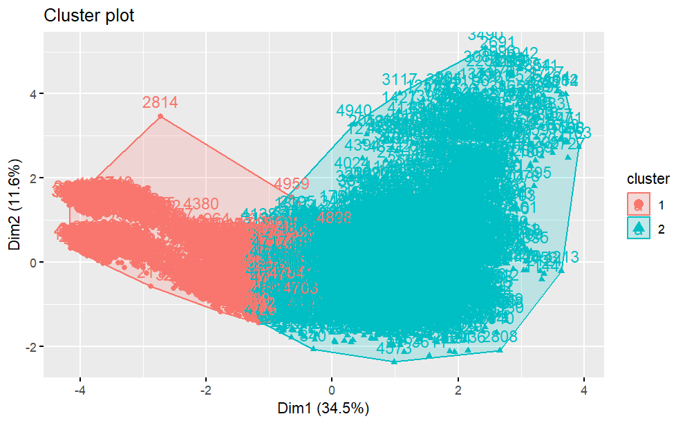

```r
library(factoextra)
fviz_cluster(kmeans.result, data = brain_stroke)
```

### K-means clustering, K= 3 Clusters

```r
# run k-means clustering to find 3 clusters
#set a seed for random number generation  to make the results reproducible
set.seed(8953)
kmeans.result <- kmeans(brain_stroke, 3)
# print the clusterng result
kmeans.result
```

### total within-cluster-sum of square

```r
#total within-cluster-sum of square
twss <- sum(kmeans.result$withinss)
print(twss)
```

The total within-cluster sum of squares (WSS) for 3 clusters is 14981.07. This metric gauges the sum of squared distances between data points and their assigned cluster centroids. In the context of the elbow method, the WSS is a criterion for evaluating the goodness of clustering. A lower WSS indicates more compact and cohesive clusters.

#### Visualize clustering (3 clusters)

```r
# visualize clustering (3 clusters)
install.packages("factoextra")
library(factoextra)
fviz_cluster(kmeans.result, data = brain_stroke)
```

#### Another visualization (3 clusters)

```r
library(factoextra)
fviz_cluster(list(data = brain_stroke, cluster = kmeans.result$cluster),
             ellipse.type = "norm", geom = "point", stand = FALSE,
             palette = "jco", ggtheme = theme_classic())
```

#### Average silhouette for each clusters (3 clusters)

```r
#average silhouette for each clusters (3 clusters)
library(cluster)
avg_sil <- silhouette(kmeans.result$cluster,dist(brain_stroke)) #a dissimilarity object inheriting from class dist or coercible to one. If not specified, dmatrix must be.
fviz_silhouette(avg_sil)#k-means clustering with estimating k and initializations
```

The silhouette plot displays silhouette values for each data point in the dataset. Silhouette values measure how similar an object is to its own cluster (cohesion) compared to other clusters (separation). Silhouette values range from -1 to 1, where a high value indicates that the object is well matched to its own cluster and poorly matched to neighboring clusters, This plot shows that the avarege sillhoutte for 3 clusters = 0.25

```r
# visualize clustering (3 clusters)
install.packages("factoextra")
```

[output not shown]

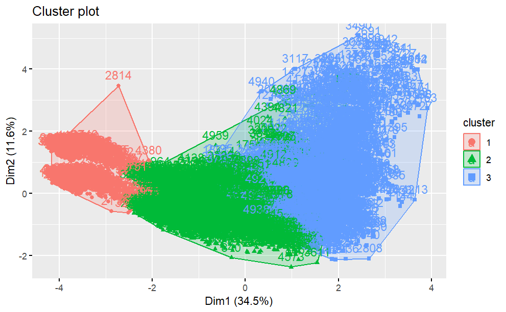

```r
library(factoextra)
fviz_cluster(kmeans.result, data = brain_stroke)
```

### K-means clustering, K= 4 Clusters

```r
# run k-means clustering to find 4 clusters
#set a seed for random number generation  to make the results reproducible
set.seed(8953)
kmeans.result <- kmeans(brain_stroke, 4)
# print the clusterng result
kmeans.result
```

The K-means clustering resulted in 4 clusters with varying sizes: 1456, 1428, 1412, and 685 observations in each cluster, respectively. The cluster means provide insights into the characteristics of each group, indicating differences in features such as age, gender, hypertension, and other variables. The clustering vector assigns each observation to a specific cluster, reflecting the group to which it belongs. The within-cluster sum of squares (WSS) for each cluster shows the compactness of the clusters, with lower WSS values indicating more internally homogeneous groups. In this case, the WSS values are 3894.58, 3822.11, 4326.56, and 801.10 for clusters 1 to 4, respectively. The between-cluster sum of squares (54.4% of total SS) suggests good separation among the clusters. Interpretation of the results should consider both the WSS and between-cluster SS to determine the optimal balance of cluster cohesion and separation for the given context.

### total within-cluster-sum of square

```r
#total within-cluster-sum of square
twss <- sum(kmeans.result$withinss)
print(twss)
```

The total within-cluster sum of squares (WSS) for 4 clusters is 12844.35. The WSS is a key in the elbow method for evaluating the quality of clustering. A lower WSS signifies more compact and internally homogeneous clusters.

#### Visualize clustering (4 clusters)

```r
# visualize clustering (4 clusters)
install.packages("factoextra")
library(factoextra)
fviz_cluster(kmeans.result, data = brain_stroke)
```

#### Another visualization (4 clusters)

```r
library(factoextra)
fviz_cluster(list(data = brain_stroke, cluster = kmeans.result$cluster),
             ellipse.type = "norm", geom = "point", stand = FALSE,
             palette = "jco", ggtheme = theme_classic())
```

#### Average silhouette for each clusters (4 clusters)

```r
#average silhouette for each clusters (4 cluster)
library(cluster)
avg_sil <- silhouette(kmeans.result$cluster,dist(brain_stroke)) #a dissimilarity object inheriting from class dist or coercible to one. If not specified, dmatrix must be.
fviz_silhouette(avg_sil)#k-means clustering with estimating k and initializations
```

#### BCubed when cluster size=4

```r
#BCubed when cluster size=4
cluster_assignments <- c(kmeans.result$cluster)
ground_truth_labels <- c(datasetbrainstroke$stroke)

if (length(cluster_assignments) > length(ground_truth_labels)) {
  cluster_assignments <- cluster_assignments[1:length(ground_truth_labels)]
} else if (length(cluster_assignments) < length(ground_truth_labels)) {
  ground_truth_labels <- ground_truth_labels[1:length(cluster_assignments)]
}

data <- data.frame(cluster = cluster_assignments, label = ground_truth_labels)

# Function to calculate BCubed precision and recall
calculate_bcubed_metrics <- function(data) {
  n <- nrow(data)
  precision_sum <- 0
  recall_sum <- 0

  for (i in 1:n) {
    cluster <- data$cluster[i]
    label <- data$label[i]

# Count the number of items from the same category within the same cluster
same_category_same_cluster <- sum(data$label[data$cluster == cluster] == label)

# Count the total number of items in the same cluster
total_same_cluster <- sum(data$cluster == cluster)

# Count the total number of items with the same category
total_same_category <- sum(data$label == label)

# Calculate precision and recall for the current item and add them to the sums
precision_sum <- precision_sum + same_category_same_cluster /total_same_cluster
recall_sum <- recall_sum + same_category_same_cluster / total_same_category
  }

  # Calculate average precision and recall
  precision <- precision_sum / n
  recall <- recall_sum / n

  return(list(precision = precision, recall = recall))
}

# Calculate BCubed precision and recall
metrics <- calculate_bcubed_metrics(data)

# Extract precision and recall from the metrics
precision <- metrics$precision
recall <- metrics$recall

# Print the results
cat("BCubed Precision:", precision, "\n")
cat("BCubed Recall:", recall, "\n")
```

### Total within-cluster sum of square (Elbow method)

```r
library(factoextra)
fviz_nbclust(brain_stroke, kmeans, method = "wss")
```

```r
# 3- Elbow method
#fviz_nbclust() with within cluster sums of squares (wss) method
library(factoextra)
fviz_nbclust(brain_stroke, kmeans, method = "wss") +
  geom_vline(xintercept = 4 , linetype = 2)+
  labs(subtitle = "Elbow method")
```

The plot depicts the elbow method used to determine the optimal number of clusters in k-means clustering for the brain stroke dataset. At k=2, the WSS is 18358.56, at k=3 it decreases to 14981.07, and at k= 4 it further reduces to 12844.35. The vertical dashed line at k=4 suggests a potential optimal number of clusters.

### Average Silhouette

```r
library(factoextra)
fviz_nbclust(brain_stroke, kmeans, method = "silhouette")
```

##### This code performs k-means clustering multiple times with different initializations and estimates the optimal number of clusters. It then visualizes the clustering results using a cluster plot. This process can help determine the appropriate number of clusters and gain insights into the structure of the data.

```r
install.packages("fpc")
library(fpc)
#kmeansruns() : It calls  kmeans() to perform  k-means clustering
#It initializes the k-means algorithm several times with random points from the data set as means.
#It estimates the number of clusters by Calinski Harabasz index or average silhouette width
kmeansruns.result <- kmeansruns(brain_stroke)
kmeansruns.result
fviz_cluster(kmeansruns.result, data = brain_stroke)
```

### Comparing the result of BCubed precision and recall

As the number of clusters increases from 2 to 4, the precision scores remain consistently high, hovering around the range of 0.907 to 0.910. However, the recall scores show a downward trend with an increase in the number of clusters. Recall decreases from 0.610 for k=2 down to 0.276 for k=4. This trend implies that while the model excels in accurately assigning items to clusters (evidenced by the high precision), it struggles more to capture all the relevant items within these clusters as the number of clusters increases. Balancing precision and recall becomes increasingly challenging as the cluster count rises.

1. **2 Clusters:**
   - High precision (0.9071407): Indicates that instances within each cluster are very similar, and there are fewer false positives.
   - Moderate recall (0.6096986): Suggests that not all instances of the true positive group are captured, but the captured instances are highly accurate.
2. **3 Clusters:**
   - Slightly higher precision (0.909903): Similar to 2 clusters, indicating high accuracy within each cluster.
   - Lower recall (0.410234): Indicates that more instances of the true positive group might be missed compared to 2 clusters.
3. **4 Clusters:**
   - Similar precision (0.9085269) to 2 and 3 clusters.
   - Lower recall (0.2755282): Indicates that more instances of the true positive group are being missed compared to 2 and 3 clusters.

Consideration for Classification Over Clustering

Our clusters are overlapping, it suggest that the dataset might be better suited for classification than clustering. Here’s why:

Inherent Structure: Clustering is for discovering natural structures, while classification thrives when clear class boundaries exist.

Visualization: Overlapping clusters might mean that our data lacks well-defined groupings, favoring classification.

Feature Alignment: Features chosen for clustering may not represent natural clusters but could align with class boundaries.

Consider Classification Models: Supervised models like decision trees or random forests may better capture the patterns in your labeled data.

#### Overall best cluster size

| Cluster size | k=2(Best) | k=3 | k=4 |
| --- | --- | --- | --- |
| Average Silhouette width for each cluster | cluster1 = 0.39 cluster2 = 0.30 | cluster1 = 0.60 cluster2 = 0.17 cluster3 = 0.20 | cluster1 = 0.20 cluster2 = 0.19 cluster3 = 0.15 cluster4 = 0.58 |
| Average Silhouette width for all clusters | 0.33 | 0.25 | 0.24 |
| Total w i t hin-cluster sum of square | 18358.56 | 14981.07 | 12844.35 |
| BCubed precision | 0.9071407 | 0.909903 | 0.9085269 |
| BCubed recall | 0.6096986 | 0.410234 | 0.2755282 |
| V i sualization | all of the figures is shown above | all of the figures is shown above | all of the figures is shown above |

## Classification

Classification is a powerful supervised machine learning approach designed to predict the category or class to which a new instance belongs. Unlike clustering, where the goal is to uncover inherent structures within data, classification leverages labeled datasets to train models and make predictions.

In the context of our analysis, we will explore a dataset related to brain stroke prediction using classification techniques. The objective is to train a model on existing data, learning patterns that link specific features to the likelihood of stroke occurrence. This predictive model can then be applied to new, unseen data to classify instances into relevant categories.

## Balance

Acknowledging the presence of imbalanced data in our dataset, we understand that addressing this imbalance is essential to improve the overall output quality. Therefore, we have applied the provided code to address this issue.

```r
# Install and load the caret package if not already installed
if (!requireNamespace("caret", quietly = TRUE)) {
  install.packages("caret")
}

# Load the caret package
library(caret)

# Check data dimensions
print(dim(datasetbrainstroke))

# Check if 'stroke' is present
if (!"stroke" %in% colnames(datasetbrainstroke)) {
  stop("Column 'stroke' not found in the data.")
}

# Convert 'stroke' to a factor (if not already)
datasetbrainstroke$stroke <- as.factor(datasetbrainstroke$stroke)

# Upscale the data
datasetbrainstroke <- upSample(datasetbrainstroke[, -11], datasetbrainstroke$stroke, yname = "stroke")

# Checking the number of stroke/non-stroke observations
prop.table(table(datasetbrainstroke$stroke))
table(datasetbrainstroke$stroke)

# Create a barplot to visualize the distribution after oversampling
barplot(table(datasetbrainstroke$stroke), main = "Data after oversampling", xlab = "Stroke", ylab = "observations")
```

We picked the holdout method for classification because it’s good for checking how well the model works on new data in my dataset . It’s simple and quick, making it easier to compare different models and adjust settings. This method works well for medium to large datasets and situations where we need a straightforward evaluation.

In this part ,we will apply various techniques for attribute selection, including the Gini index, Gain ratio, and information gain, to build a decision tree model

# 1.Split the datasets into two subsets: Training(70%) and Testing(30%):

```r
install.packages("party")
```

[output not shown]

```r
# 1.Split the datasets into two subsets: Training(70%) and Testing(30%):

set.seed(1234)
ind <- sample(2, nrow(brain_stroke), replace = TRUE, prob = c(0.7, 0.3))
train.data <- brain_stroke[ind == 1, ]
test.data <- brain_stroke[ind == 2, ]

dim(train.data)
```

[output not shown]

```r
dim(test.data)
```

```
[1] 2801   11
```

```r
head(test.data)
```

[output not shown]

```r
datasetbrainstroke$gender <- as.factor(datasetbrainstroke$gender)
datasetbrainstroke$age<- as.factor(datasetbrainstroke$age)
datasetbrainstroke$hypertension <- as.factor(datasetbrainstroke$hypertension)
datasetbrainstroke$heart_disease <- as.factor(datasetbrainstroke$heart_disease)
datasetbrainstroke$ever_married <- as.factor(datasetbrainstroke$ever_married)
datasetbrainstroke$work_type <- as.factor(datasetbrainstroke$work_type)
datasetbrainstroke$Residence_type <- as.factor(datasetbrainstroke$Residence_type)
datasetbrainstroke$avg_glucose_level <- as.factor(datasetbrainstroke$avg_glucose_level)
datasetbrainstroke$smoking_status <- as.factor(datasetbrainstroke$smoking_status)
datasetbrainstroke$stroke <- as.factor(datasetbrainstroke$stroke)
datasetbrainstroke$bmi <- as.factor(datasetbrainstroke$bmi)


train.data$Residence_type <- as.factor(train.data$Residence_type)
train.data$ever_married <- as.factor(train.data$ever_married)
train.data$gender <- as.factor(train.data$gender)
train.data$work_type <- as.factor(train.data$work_type)
train.data$smoking_status <- as.factor(train.data$smoking_status)
train.data$stroke <- as.factor(train.data$stroke)
train.data$bmi <- as.factor(train.data$bmi)
train.data$age<- as.factor(train.data$age)
train.data$hypertension <- as.factor(train.data$hypertension)
train.data$heart_disease <- as.factor(train.data$heart_disease)
train.data$avg_glucose_level <- as.factor(train.data$avg_glucose_level)


test.data$Residence_type <- as.factor(test.data$Residence_type)
test.data$ever_married <- as.factor(test.data$ever_married)
test.data$gender <- as.factor(test.data$gender)
test.data$work_type <- as.factor(test.data$work_type)
test.data$smoking_status <- as.factor(test.data$smoking_status)
test.data$stroke <- as.factor(test.data$stroke)
test.data$bmi <- as.factor(test.data$bmi)
test.data$age<- as.factor(test.data$age)
test.data$hypertension <- as.factor(test.data$hypertension)
test.data$heart_disease <- as.factor(test.data$heart_disease)
test.data$avg_glucose_level <- as.factor(test.data$avg_glucose_level)
```

```r
levels(train.data$Residence_type)
levels(test.data$Residence_type)

levels(train.data$gender)
levels(test.data$gender)

levels(train.data$age)
levels(test.data$age)
#not the same level
test.data$age <- factor(test.data$age, levels = levels(train.data$age))


levels(train.data$hypertension)
levels(test.data$hypertension)

levels(train.data$heart_disease)
levels(test.data$heart_disease)

levels(train.data$ever_married)
levels(test.data$ever_married)

levels(train.data$work_type)
levels(test.data$work_type)

levels(train.data$avg_glucose_level)
levels(test.data$avg_glucose_level)
#not the same level
test.data$avg_glucose_level <- factor(test.data$avg_glucose_level, levels = levels(train.data$avg_glucose_level))

levels(train.data$smoking_status)
levels(test.data$smoking_status)

levels(train.data$stroke)
levels(test.data$stroke)

levels(train.data$bmi)
levels(test.data$bmi)
#not the same level
test.data$bmi <- factor(test.data$bmi, levels = levels(train.data$bmi))
```

## information gain

```r
library(party)

myFormula <- stroke ~ Residence_type+ever_married+gender+work_type+smoking_status+avg_glucose_level+heart_disease+hypertension+age+bmi


brain_stroke.ctree <- ctree(myFormula, data = train.data)
predictions <- predict(brain_stroke.ctree, newdata = test.data, type = "response")
confusion_matrix <- table(predictions, test.data$stroke)
print(confusion_matrix)
plot(brain_stroke.ctree)

table(predict(brain_stroke.ctree), train.data$stroke)
```

# Print and plot the tree:

```r
print(brain_stroke.ctree)
plot(brain_stroke.ctree, type="simple")
```

#confusion matrix

```r
install.packages("partykit")
library(party)
library(partykit)
library(RWeka)
library(caret)
library(rpart)
library(rpart.plot)
testPred<- predict(brain_stroke.ctree,newdata=test.data)
results<- confusionMatrix(testPred,test.data$stroke)
print(results)
```

#Gain ratio:

```r
install.packages("RWeka")
install.packages("partykit")
library(party)
library(partykit)
library(RWeka)
library(caret)
library(rpart)
library(rpart.plot)
library(RWeka)

C45Fit <- J48(stroke~.,data=train.data)
table(predict(C45Fit), train.data$stroke)

print(C45Fit)
plot(C45Fit)
plot(C45Fit,type="simple")
```

#confusion matrix

```r
install.packages("partykit")
library(party)
library(partykit)
library(RWeka)
library(caret)
library(rpart)
library(rpart.plot)
testPred<- predict(brain_stroke.ctree,newdata=test.data)
results<- confusionMatrix(testPred,test.data$stroke)
print(results)
```

#Gini index

[figure not shown]

```r
library(rpart)
library(rpart.plot)
fit.tree=rpart(stroke~., data=train.data, method="class",cp=0.008)
pruned.tree <- prune(fit.tree, cp = 0.005)
par(mfrow = c(1, 1), mar = c(5, 5, 2, 1), cex = 1.5)
# Plot the pruned tree
rpart.plot(pruned.tree, box.palette = "auto", shadow.col = "gray", nn = TRUE)
```

```r
print(fit.tree)
```

[output not shown]

[figure not shown]

```r
rpart.plot(fit.tree)
```

```r
NA
NA
```

#cunfusion matrix

```r
library(party)
library(partykit)
library(RWeka)
library(caret)
library(rpart)
library(rpart.plot)


testPred<- predict(fit.tree,newdata=test.data,type="class")
results<- confusionMatrix(testPred,test.data$stroke,positive="1")
print(results)
```

[output not shown]

# 2.Split the datasets into two subsets: Training(80%) and Testing(20%):

```r
set.seed(1234)
ind <- sample(2, nrow(brain_stroke), replace = TRUE, prob = c(0.8, 0.2))
train.data <- brain_stroke[ind == 1, ]
test.data <- brain_stroke[ind == 2, ]

dim(train.data)
```

[output not shown]

```r
dim(test.data)
```

```
[1] 1884   11
```

```r
head(test.data)
```

[output not shown]

```r
NA
```

#information gain

```r
library(party)

myFormula <- stroke ~ Residence_type + ever_married+ gender+work_type+smoking_status+avg_glucose_level+heart_disease+hypertension+bmi+age


brain_stroke.ctree <- ctree(myFormula, data = train.data)
predictions <- predict(brain_stroke.ctree, newdata = test.data, type = "response")
confusion_matrix <- table(predictions, test.data$stroke)
print(confusion_matrix)
plot(brain_stroke.ctree)

table(predict(brain_stroke.ctree), train.data$stroke)
```

# 4.Print and plot the tree:

```r
print(brain_stroke.ctree)
plot(brain_stroke.ctree, type="simple")
```

```r
# Define levels
lvs <- c("normal", "abnormal")

# Rest of the code remains the same
truth <- factor(rep(lvs, times = c(86, 258)),
                levels = rev(lvs))
pred <- factor(
               c(
                 rep(lvs, times = c(54, 32)),
                 rep(lvs, times = c(27, 231))),
               levels = rev(lvs))

xtab <- table(pred, truth)

confusionMatrix(xtab)
confusionMatrix(pred, truth)
confusionMatrix(xtab, prevalence = 0.25)
```

#Gain ratio:

```r
install.packages("RWeka")
install.packages("partykit")
library(party)
library(partykit)
library(RWeka)
library(caret)
library(rpart)
library(rpart.plot)
library(RWeka)

C45Fit <- J48(stroke~.,data=train.data)
table(predict(C45Fit), train.data$stroke)

print(C45Fit)
plot(C45Fit)
plot(C45Fit,type="simple")
```

#cunfusion matrix

```r
library(party)
library(partykit)
library(RWeka)
library(caret)
library(rpart)
library(rpart.plot)


testPred<- predict(fit.tree,newdata=test.data,type="class")
results<- confusionMatrix(testPred,test.data$stroke,positive="1")
print(results)
```

#Gini index

[figure not shown]

```r
library(party)
library(partykit)
library(RWeka)
library(caret)
library(rpart)
library(rpart.plot)
library(caret)

fit.tree=rpart(stroke~., data=train.data, method="class",cp=0.008)
pruned.tree <- prune(fit.tree, cp = 0.005)
par(mfrow = c(1, 1), mar = c(5, 5, 2, 1), cex = 1.5)
# Plot the pruned tree
rpart.plot(pruned.tree, box.palette = "auto", shadow.col = "gray", nn = TRUE)
```

```r
print(fit.tree)
```

[output not shown]

[figure not shown]

```r
rpart.plot(fit.tree)
```

```r
NA
NA
```

#cunfusion matrix

```r
library(party)
library(partykit)
library(RWeka)
library(caret)
library(rpart)
library(rpart.plot)


testPred<- predict(fit.tree,newdata=test.data,type="class")
results<- confusionMatrix(testPred,test.data$stroke,positive="1")
print(results)
```

[output not shown]